# R Short Course, Part 3

[R Short Course](https://github.com/jbhender/CSCAR_Workshops/tree/main/rsc/)

## Part 3

In part 3, we’ll discuss the following programming tools: functions, logical comparisons, conditionals, and iteration.

### Recommended Reading

The following chapters in *R for Data Science*

- [Program Introduction](https://r4ds.had.co.nz/program-intro.html)
- [Functions](http://r4ds.had.co.nz/functions.html)
- [Iteration](https://r4ds.had.co.nz/iteration.html)

From *Hands on Programming with R*:

- Sections [2.3-2.5](https://rstudio-education.github.io/hopr/basics.html#functions)
- [Loops](https://rstudio-education.github.io/hopr/loops.html)

From the [The tidyverse style guide](https://style.tidyverse.org/):

- Section 2.3 [Function Calls](https://style.tidyverse.org/syntax.html#function-calls),
- Section 2.4, [Control Flow](https://style.tidyverse.org/syntax.html#control-flow)
- Chapter 3, [Functions](https://style.tidyverse.org/functions.html)

For a more technical treatment, the following chapter from *Advanced R* is most relevant.

- [Functions](http://adv-r.had.co.nz/Functions.html).

## Functions

**R** identifies functions by the `func()` construction. Functions are simply collections of commands that do something. Functions take *arguments* which can be used to specify *which* objects to operate on and *what* values of parameters are used. You can use `help(func)` to see what a function is used for and what arguments it expects, i.e. `help(sprintf)`.

### Arguments

Functions will often have multiple arguments. Some arguments have default values, others do not. All arguments without default values must be passed to a function. Arguments can be passed by name or position. For instance,

```r
x = runif(n = 5, min = 0, max = 1)
y = runif(5, 0, 1)
z = runif(5)
round(cbind(x, y, z), 1)
```

```
##        x   y   z
## [1,] 0.4 0.6 0.2
## [2,] 0.4 0.8 1.0
## [3,] 1.0 0.5 0.0
## [4,] 0.1 0.2 0.6
## [5,] 0.6 0.5 0.2
```

both generate 5 numbers from a Uniform(0, 1) distribution.

Arguments passed by name need not be in order:

```r
w = runif(min = 0, max = 1, n = 5)
u = runif(min = 0, max = 1, 5) # This also works but is bad style.
round(rbind(u = u, w = w), 1)
```

```
##   [,1] [,2] [,3] [,4] [,5]
## u  0.4  0.4  0.3  0.4  0.3
## w  0.0  0.8  0.5  0.1  0.4
```

### *Style notes*

- Values for function arguments with default values should be passed by name, not position.
- Commonly used and required function arguments can be passed by position.
- It’s never bad style to pass by name rather than value.

### Writing Functions

You can create your own functions in **R**. Use functions for tasks that you repeat often in order to make your scripts more easily readable and modifiable. A good rule of thumb is never to copy and paste the same text more than twice –use a function instead.

It can also be a good practice to use functions to break complex processes into parts, especially if these parts are used with control flow statements such as loops or conditionals. This will make your code easier to read, debug, and maintain.

### Example Functions

```r
z_score1 = function(x) {
  #standardize a vector using z-scores (center to mean 0, scale to sd 1)
  #inputs: x - a numeric vector
  #outputs: the z-scores for x
  xbar = mean(x)
  s = sd(x)
  z = (x - mean(x)) / s

  return(z)
}
```

The `return` statement is not strictly necessary, but can make complex functions more readable. It is good practice to avoid creating intermediate objects to store values only used once.

```r
z_score2 = function(x){
  #standardize a vector using z-scores (center to mean 0, scale to sd 1)
  #inputs: x - a numeric vector
  #outputs: the z-scores for x
  {x - mean(x)} / sd(x)
}
```

```r
x = rnorm(10, 3, 1) ## generate some normally distributed values
round(cbind(x, 'Z1' = z_score1(x), 'Z2' = z_score2(x) ), 1)
```

```
##         x   Z1   Z2
##  [1,] 3.4  0.3  0.3
##  [2,] 4.6  1.2  1.2
##  [3,] 4.2  0.9  0.9
##  [4,] 2.7 -0.3 -0.3
##  [5,] 5.1  1.6  1.6
##  [6,] 1.1 -1.6 -1.6
##  [7,] 2.8 -0.2 -0.2
##  [8,] 2.7 -0.3 -0.3
##  [9,] 2.0 -0.8 -0.8
## [10,] 1.9 -0.9 -0.9
```

### Default parameters

We can set default values for parameters using the construction `parameter = xx` in the function definition.

```r
# function to compute z-scores
z_score3 = function(x, na.rm = TRUE){
  {x - mean(x, na.rm = na.rm)} / sd(x, na.rm = na.rm)
}
```

```r
x = c(NA, x, NA)
round(cbind(x, 'Z1' = z_score1(x), 'Z2' = z_score2(x), 'Z3' = z_score3(x)), 1)
```

```
##         x Z1 Z2   Z3
##  [1,]  NA NA NA   NA
##  [2,] 3.4 NA NA  0.3
##  [3,] 4.6 NA NA  1.2
##  [4,] 4.2 NA NA  0.9
##  [5,] 2.7 NA NA -0.3
##  [6,] 5.1 NA NA  1.6
##  [7,] 1.1 NA NA -1.6
##  [8,] 2.8 NA NA -0.2
##  [9,] 2.7 NA NA -0.3
## [10,] 2.0 NA NA -0.8
## [11,] 1.9 NA NA -0.9
## [12,]  NA NA NA   NA
```

### Scope

Scoping refers to how **R** looks up the value associated with an object referred to by name. There are two types of scoping – lexical and dynamic – but we will concern ourselves only with lexical scoping here. There are four keys to understanding scoping:

- environments
- name masking
- variables vs functions
- dynamic look up and lazy evaluation.

An environment can be thought of as a context in which names are associated with objects. Each time a function is called, it generates a new environment for the computation.

Consider the following examples:

```r
ls()
```

```
## [1] "u"        "w"        "x"        "y"        "z"        "z_score1" "z_score2"
## [8] "z_score3"
```

```r
f1 = function() {
  f1_message = "I'm defined inside of f!"  # `message` is a function in base
  ls()
}
f1()
```

```
## [1] "f1_message"
```

```r
exists('f1')
```

```
## [1] TRUE
```

```r
exists('f1_message')
```

```
## [1] FALSE
```

```r
environment()
```

```
## <environment: R_GlobalEnv>
```

```r
f2 = function(){
  environment()
}
f2()
```

```
## <environment: 0x7f90ca0baab8>
```

```r
rm(f1, f2)
```

Name masking refers to *where* and *in what order* **R** looks for object names.  
When we call `f1` above, **R** first looks in the current environment which happens to be the global environment. The call to `ls()` however, happens within the environment created by the function call and hence returns only the objects defined in the local environment.

When an environment is created, it gets nested within the current environment referred to as the “parent environment”. When an object is referenced we first look in the current environment and move recursively up through parent environments until we find a value bound to that name.

Name masking refers to the notion that objects of the same name can exist in different environments. Consider these examples:

```r
y = x = 'I came from outside of f!'
f3 = function(){
  x =  'I came from inside of x!'
  list(x = x, y = y)
}
f3()
```

```
## $x
## [1] "I came from inside of x!"
##
## $y
## [1] "I came from outside of f!"
```

```r
x
```

```
## [1] "I came from outside of f!"
```

```r
mean = function(x){
  sum(x)
}
mean(1:10)
```

```
## [1] 55
```

```r
base::mean(1:10)
```

```
## [1] 5.5
```

```r
rm(mean)
```

**R** also uses dynamic look up, meaning *values are searched for when a function is called* not when it is *created*. In the example above, `y` was defined in the global environment rather than within the function body. This means the value returned by `f3` depends on the value of `y` in the global environment *when `f3` is executed*. You should generally avoid this, but there are occasions where it can be useful.

```r
y = "I have been reinvented!"
f3()
```

```
## $x
## [1] "I came from inside of x!"
##
## $y
## [1] "I have been reinvented!"
```

Finally, lazy evaluation means **R** only evaluates function arguments if and when they are actually used.

```r
f4 = function(x){
  #x
  45
}

f4( x = stop("Let's pass an error.") )
```

```
## [1] 45
```

Move `x` out of the comment to see what happens if we evaluate it.

## Logicals

**R** has three reserved words of type ‘logical’:

```r
typeof(TRUE)
```

```
## [1] "logical"
```

```r
typeof(FALSE)
```

```
## [1] "logical"
```

```r
typeof(NA)
```

```
## [1] "logical"
```

```r
if ( TRUE && T ) {
  print('Synonyms')
}
```

```
## [1] "Synonyms"
```

```r
if ( FALSE || F ){
  print('Synonyms')
}
```

While `T` and `F` are equivalent to `TRUE` and `FALSE` it is best to always use the full words. You should also avoid using `T` or `F` as names for objects or function arguments.

### *Style notes*

- Always use `TRUE` and `FALSE` rather than `T` or `F` for logical vectors.
- Avoid naming objects or function arguments with any of these four reserved words: `TRUE`, `FALSE`, `T`, `F`.

### Boolean comparisons

Boolean operators are useful for generating logical vectors conditionally on the values in one or more other vectors.

Here are the essential Boolean operators in R:

| Operator | Meaning |
| --- | --- |
| `==` | equal |
| `!=` | not equal |
| `>`, `>=` | greater than (or equal to) |
| `<`, `<=` | less than (or equal to) |
| `&&` | scalar AND |
| `\|\|` | scalar OR |
| `&` | vectorized AND |
| `\|` | vectorized OR |
| `!` | negation (`!TRUE == FALSE` and `!FALSE == TRUE`) |

Boolean comparisons create logical vectors:

```r
{2 * 3} == 6     # test equality with ==
```

```
## [1] TRUE
```

```r
{2 + 2} != 5     # use != for 'not equal'
```

```
## [1] TRUE
```

```r
sqrt(70) > 8     # comparison operators: >, >=, <, <=
```

```
## [1] TRUE
```

```r
sqrt(64) >= 8
```

```
## [1] TRUE
```

```r
!{2 == 3}        # Use not to negate or 'flip' a logical
```

```
## [1] TRUE
```

Comparison operators are vectorized:

```r
1:10 > 5
```

```
##  [1] FALSE FALSE FALSE FALSE FALSE  TRUE  TRUE  TRUE  TRUE  TRUE
```

You can can combine operators using ‘and (&)’ or ‘or (|)’:

```r
{2 + 2} == 4 | {2 + 2} == 5 # An or statement asks if either statement is true
```

```
## [1] TRUE
```

```r
{2 + 2} == 4 & {2 + 2} == 5 # And requires both to be true
```

```
## [1] FALSE
```

Note the difference between the single (vectorized) and double versions:

```r
even = {1:10 %% 2} == 0
div4 = {1:10 %% 4} == 0

even | div4
```

```
##  [1] FALSE  TRUE FALSE  TRUE FALSE  TRUE FALSE  TRUE FALSE  TRUE
```

```r
even || div4
```

```
## [1] FALSE
```

```r
even & div4
```

```
##  [1] FALSE FALSE FALSE  TRUE FALSE FALSE FALSE  TRUE FALSE FALSE
```

```r
even && div4
```

```
## [1] FALSE
```

The following functions are also useful for working with logical vectors.

| Operator | Meaning |
| --- | --- |
| `any()` | are ANY of the elements true |
| `all()` | are ALL of the elements true |
| `which()` | find the position or index of all true values |

Use `any` or `all` to efficiently check for the presence of any `TRUE` or `FALSE` in a logical vector.

```r
any(even)
```

```
## [1] TRUE
```

```r
all(even)
```

```
## [1] FALSE
```

```r
which(even)
```

```
## [1]  2  4  6  8 10
```

### *Style notes*

- Always include spaces on either side of binary operators – including Boolean comparisons.

### Using `which()`

The `which()` function returns the elements of a logical vector that return true:

```r
which( {1:5}^2 > 10 )
```

```
## [1] 4 5
```

A combination of `which` and a logical vector can be used to subset data frames by position.

```r
head(mtcars)
```

```
##                    mpg cyl disp  hp drat    wt  qsec vs am gear carb
## Mazda RX4         21.0   6  160 110 3.90 2.620 16.46  0  1    4    4
## Mazda RX4 Wag     21.0   6  160 110 3.90 2.875 17.02  0  1    4    4
## Datsun 710        22.8   4  108  93 3.85 2.320 18.61  1  1    4    1
## Hornet 4 Drive    21.4   6  258 110 3.08 3.215 19.44  1  0    3    1
## Hornet Sportabout 18.7   8  360 175 3.15 3.440 17.02  0  0    3    2
## Valiant           18.1   6  225 105 2.76 3.460 20.22  1  0    3    1
```

```r
mtcars[ which( mtcars$mpg > 30 ), ]
```

```
##                 mpg cyl disp  hp drat    wt  qsec vs am gear carb
## Fiat 128       32.4   4 78.7  66 4.08 2.200 19.47  1  1    4    1
## Honda Civic    30.4   4 75.7  52 4.93 1.615 18.52  1  1    4    2
## Toyota Corolla 33.9   4 71.1  65 4.22 1.835 19.90  1  1    4    1
## Lotus Europa   30.4   4 95.1 113 3.77 1.513 16.90  1  1    5    2
```

However, it’s generally clearer to use the `subset()` method.

```r
subset(mtcars,  mpg > 30)
```

```
##                 mpg cyl disp  hp drat    wt  qsec vs am gear carb
## Fiat 128       32.4   4 78.7  66 4.08 2.200 19.47  1  1    4    1
## Honda Civic    30.4   4 75.7  52 4.93 1.615 18.52  1  1    4    2
## Toyota Corolla 33.9   4 71.1  65 4.22 1.835 19.90  1  1    4    1
## Lotus Europa   30.4   4 95.1 113 3.77 1.513 16.90  1  1    5    2
```

## Conditionals

In programming, we often need to execute a piece of code only if some condition is true. Here are some of the **R** tools for doing this.

### if statements

The workhorse for conditional execution in **R** is the `if` statement.  
In the syntax below, note the spacing around the condition enclosed in the parentheses.

```r
if ( TRUE ) {
  print('do something if true')
}
```

```
## [1] "do something if true"
```

Use an `else` to control the flow without separately checking the condition’s negation:

```r
if ( {2 + 2} == 5 ) {
  print('the statement is true')
} else {
  print('the statement is false')
}
```

```
## [1] "the statement is false"
```

A vectorized version of the construction above is the function `ifelse()`.

```r
result = c(4, 5)
report = ifelse( {2 + 2} == result, 'true', 'false')
report
```

```
## [1] "true"  "false"
```

For more complex cases, you may want to check multiple conditions:

```r
a = -1
b = 1

if ( a * b > 0 ) {
  print('Zero is not between a and b')
} else if ( a < b ) {
    smaller = a
    larger = b
} else {
    smaller = b
    larger  = a
}

c(smaller, larger)
```

```
## [1] -1  1
```

### *Style notes*

In all of the examples above, please pay close attention to the use of spacing and indentation for clarity. Also note that the opening brace for a conditional expression should start on the same line as the `if` or `else` statement.

### switch

Use a switch when you have multiple discrete options.

Here is a simple example:

```r
cases = function(x) {
  switch(as.character(x),
    a=1,
    b=2,
    c=3,
    "Neither a, b, nor c."
  )
}
cases("a")
```

```
## [1] 1
```

```r
cases("m")
```

```
## [1] "Neither a, b, nor c."
```

```r
cases(8)
```

```
## [1] "Neither a, b, nor c."
```

Without the coercion, the final call will evaluate to `NULL`.

```r
cases2 = function(x) {
  switch(x,
    a=1,
    b=2,
    c=3,
    "Neither a, b, nor c."
  )
}
cases2_output = cases2(8)
cases2_output
```

[output not shown]

A `switch` can also be used with a numeric expression,

```r
for( i in c(-1:3, 9) ) {
  print( switch(i, 1, 2, 3, 4) )
}
```

```
## NULL
## NULL
## [1] 1
## [1] 2
## [1] 3
## NULL
```

Here is a more useful example:

```r
my_summary = function(x) {
  # Summarize a vector x
  #  inputs: x - a numeric vector or a factor
  #  output: if x is a factor, a frequency table; if x is numeric a string
  #     stating its mean and standard deviation
  switch(class(x),
         factor=table(x),
         numeric=sprintf('mean=%4.2f, sd=%4.2f', mean(x), sd(x)),
        'Only defined for factor and numeric classes.')
}

for ( var in names(iris) ) {
  cat(var, ':\n', sep = '')
  print( my_summary(iris[, var]) )
}
```

```
## Sepal.Length:
## [1] "mean=5.84, sd=0.83"
## Sepal.Width:
## [1] "mean=3.06, sd=0.44"
## Petal.Length:
## [1] "mean=3.76, sd=1.77"
## Petal.Width:
## [1] "mean=1.20, sd=0.76"
## Species:
## x
##     setosa versicolor  virginica
##         50         50         50
```

## Iteration

### `for` loops

Here is the syntax for a basic for loop in **R**

```r
for ( i in 1:10 ) {
   cat(i, '\n')
}
```

```
## 1
## 2
## 3
## 4
## 5
## 6
## 7
## 8
## 9
## 10
```

Note that both the body of the loop (between the curly brackets) and the *iterator* are evaluated within the global environment.

```r
for ( var in names(mtcars) ) {
  cat( sprintf('average %s = %4.3f', var, mean(mtcars[, var]) ), '\n')
}
```

```
## average mpg = 20.091
## average cyl = 6.188
## average disp = 230.722
## average hp = 146.688
## average drat = 3.597
## average wt = 3.217
## average qsec = 17.849
## average vs = 0.438
## average am = 0.406
## average gear = 3.688
## average carb = 2.812
```

```r
var
```

```
## [1] "carb"
```

### `while` loops

A `while` statement can be useful when you aren’t sure how many iterations are needed. Here is an example that takes a random walk and terminates if the value is more than 10 units from 0.

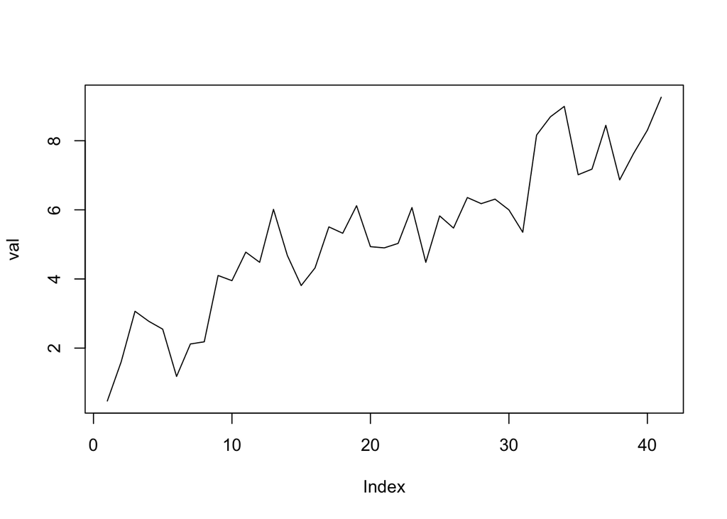

```r
maxIter = 1e3 # always limit the total iterations allowed
val = vector(mode = 'numeric', length = maxIter)
val[1] = rnorm(1) ## initialize

k = 1 # counter
while ( abs(val[k]) < 10 && k <= maxIter ) {
  val[k + 1] = val[k] + rnorm(1)
  k = k + 1
}
val = val[1:{k - 1}]

plot(val, type = 'l')
```

### control words

The following control words are useful within loops:

- `break` - break out of the currently executing loop
- `next` - move to the next iteration immediately, without executing the rest of this iteration (`continue` in other languages such as C++)

Here is an example using `next`:

```r
for ( i in 1:10 ) {
  if ( i %% 2 == 0 ) next
  cat(i,'\n')
}
```

```
## 1
## 3
## 5
## 7
## 9
```

Here is an example using `break`:

```r
x = c()
for ( i in 1:1e1 ) {
  if ( i %% 3 == 0 ) break
  x = c(x, i)
}
print(x)
```

```
## [1] 1 2
```